# Problem Set R

Jackson Taylor

November 16, 2017

```r
knitr::opts_chunk$set(echo = TRUE)
library(foreign)
```

## a.)

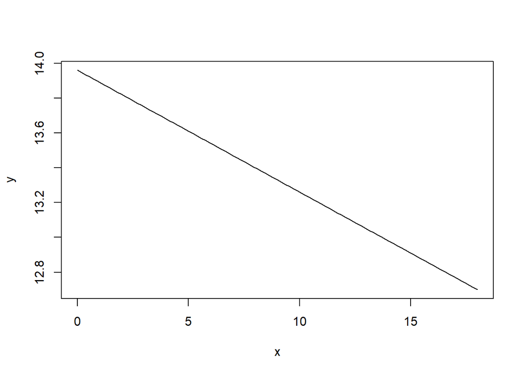

```r
curve(13.96-.07*x, from=0, to=18, ylab = "y")
```

The econometrician proposed that there is a linear relationship between and individual’s years of education and an individual’s distance to the nearest university.

## b.)

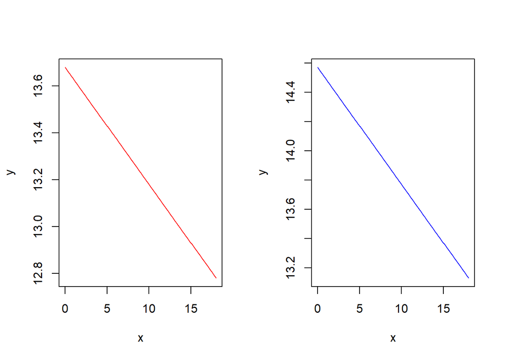

```r
par(mfrow=c(1,2))
curve((13.68-.05*x), from=0, to=18, ylab = "y", col="red")
curve(14.57-.08*x, from=0, to=18, ylab = "y", col= "blue")
```

## c.)

We can combine both function using incomehi = 0 as the base case. So, initially use Y=13.68-.05*X1. If the individual is high income, we see that the intercept changes to 14.57. So (13.68+B2)=14.57. The new equation is Y=13.68-.05*X1+.89*X2. Additional, the marginal effect of X1 changes for high income individuals changes to -.08. So (-.05+B3)=-.08. The combined equation is Y=13.68-.05*X1+.89*X2-.03*X1*X2.

## d.)

```r
CollDist = read.dta("CollegeDistance.dta")
head(CollDist)
```

```
##   female black hispanic bytest dadcoll momcoll ownhome urban cue80
## 1      0     0        0  39.15       1       0       1     1   6.2
## 2      1     0        0  48.87       0       0       1     1   6.2
## 3      0     0        0  48.74       0       0       1     1   6.2
## 4      0     1        0  40.40       0       0       1     1   6.2
## 5      1     0        0  40.48       0       0       0     1   5.6
## 6      0     0        0  54.71       0       0       1     1   5.6
##   stwmfg80 dist tuition incomehi ed
## 1     8.09  0.2 0.88915        1 12
## 2     8.09  0.2 0.88915        0 12
## 3     8.09  0.2 0.88915        0 12
## 4     8.09  0.2 0.88915        0 12
## 5     8.09  0.4 0.88915        0 13
## 6     8.09  0.4 0.88915        0 12
```

## e.)

By looking at the data, we see that (Y,X1,X2) corresponds to the (ed,dist,incomehi) variables.

Below are three scatterplots that illustrate the relationship between these variables.

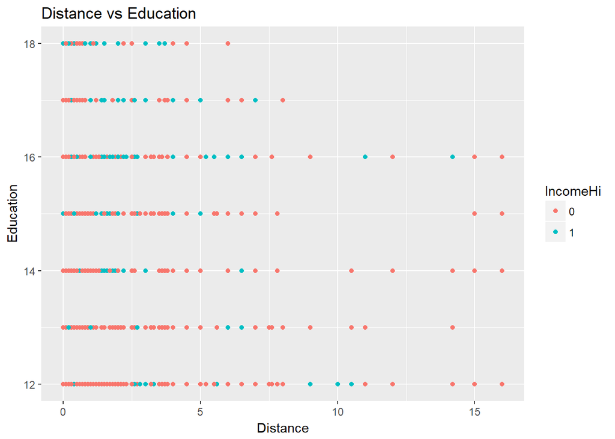

```r
library(ggplot2)
Y = CollDist$ed
X1 = CollDist$dist
X2 = as.factor(CollDist$incomehi)

data = data.frame(Education=Y, Distance=X1, IncomeHi=X2)
ggplot(data, aes(y=Education, x=Distance, color=IncomeHi)) + geom_point() + ggtitle("Distance vs Education")
```

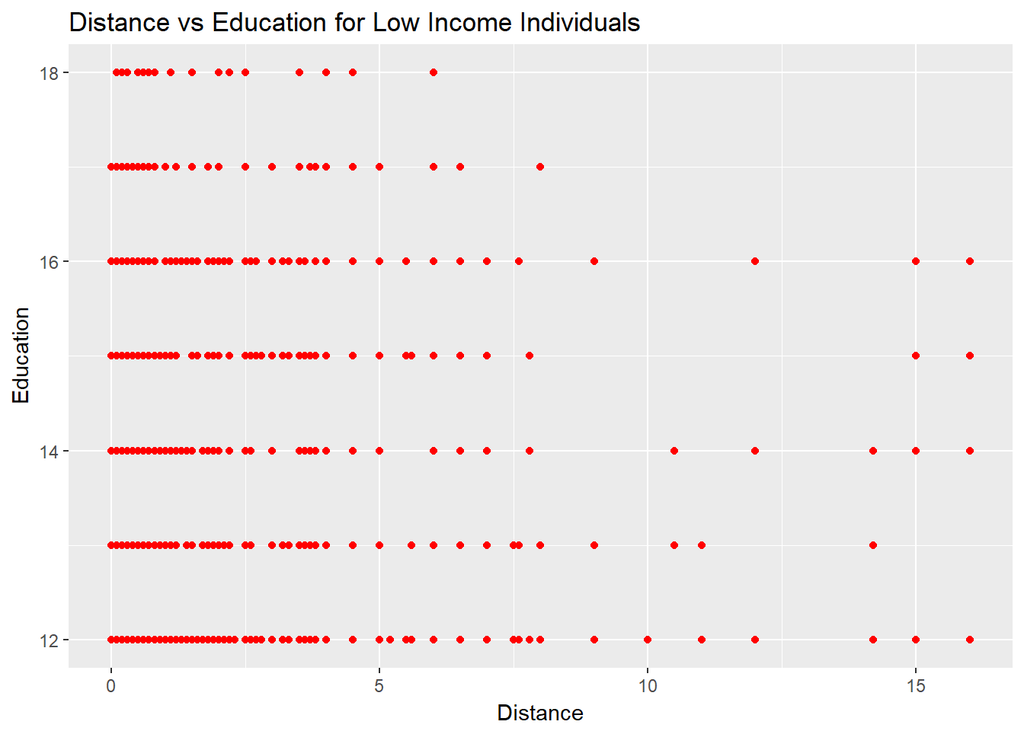

```r
ggplot(subset(data, IncomeHi==0), aes(y=Education, x=Distance)) + geom_point(color="red") + ggtitle("Distance vs Education for Low Income Individuals")
```

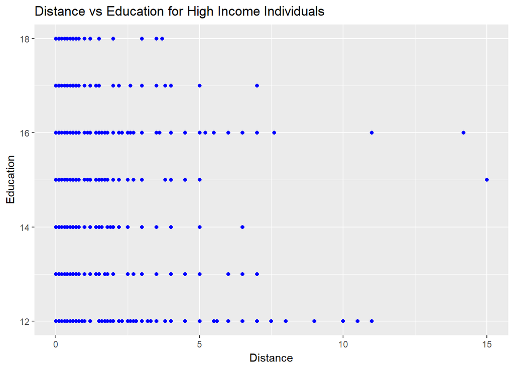

```r
ggplot(subset(data, IncomeHi==1), aes(y=Education, x=Distance)) + geom_point(color="blue") + ggtitle("Distance vs Education for High Income Individuals")
```

The first graph was slightly cluttered, so I created two different graphs, the first for low income individuals and the second for high income individuals.

Below are the same graphs with the proposed models overlaid.

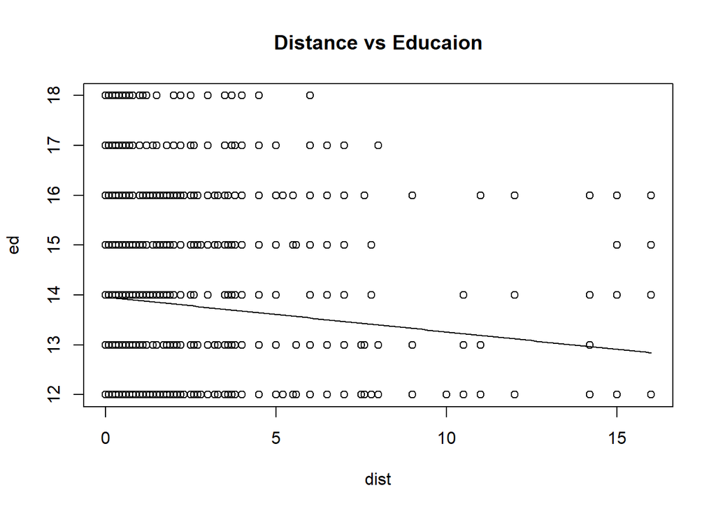

```r
plot(ed~dist,data=CollDist, main="Distance vs Educaion")
curve(13.96-.07*x, ylab = "y", add=TRUE)
```

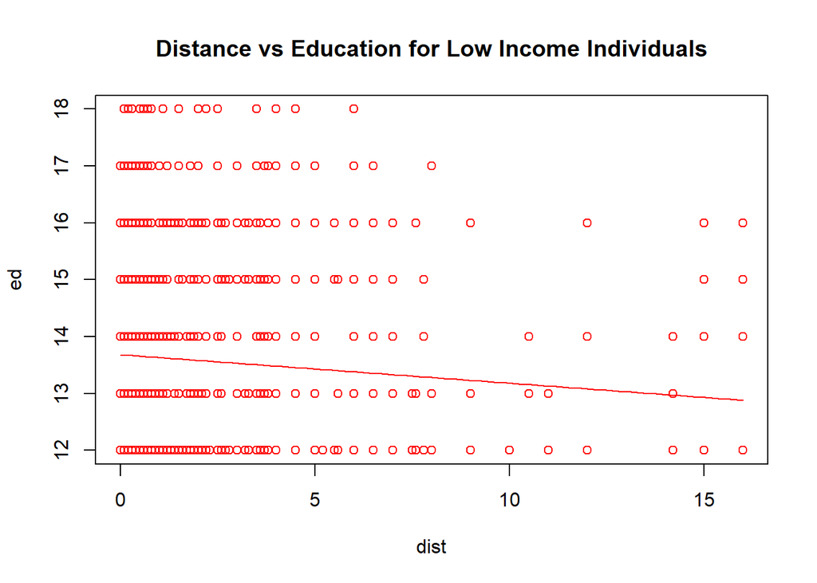

```r
plot(ed~dist,data=subset(CollDist, incomehi==0), col ="red", main ="Distance vs Education for Low Income Individuals")
curve((13.68-.05*x),ylab = "y", add=TRUE, col ="red")
```

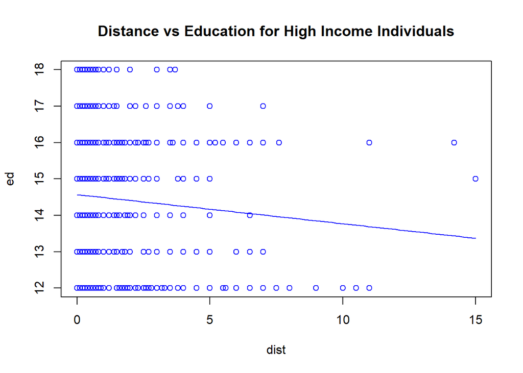

```r
plot(ed~dist,data=subset(CollDist, incomehi==1), col= "blue", main ="Distance vs Education for High Income Individuals")
curve(14.57-.08*x, ylab = "y", col= "blue", add=TRUE)
```

## f.)

```r
initmod= lm(ed~dist, data=CollDist)
initmod
```

```
##
## Call:
## lm(formula = ed ~ dist, data = CollDist)
##
## Coefficients:
## (Intercept)         dist
##    13.95586     -0.07337
```

```r
X = as.matrix(cbind(1,CollDist$dist))
Y = as.matrix(CollDist$ed)
Beta_hat = solve((t(X)%*%X))%*%t(X)%*%Y
Beta_hat
```

```
##             [,1]
## [1,] 13.95585611
## [2,] -0.07337271
```

Using both lm and “by hand”, we get the same OLS estimator for beta. These values also match the proposed model in (a).

## g.)

```r
lowmod = lm(ed~dist, data=subset(CollDist,incomehi == 0))
lowmod
```

```
##
## Call:
## lm(formula = ed ~ dist, data = subset(CollDist, incomehi == 0))
##
## Coefficients:
## (Intercept)         dist
##    13.67580     -0.05193
```

```r
X = as.matrix(cbind(1,subset(CollDist,incomehi == 0)$dist))
Y = as.matrix(subset(CollDist,incomehi == 0)$ed)
Beta_hat = solve((t(X)%*%X))%*%t(X)%*%Y
Beta_hat
```

```
##            [,1]
## [1,] 13.6758035
## [2,] -0.0519342
```

```r
himod=lm(ed~dist, data=subset(CollDist,incomehi == 1))
himod
```

```
##
## Call:
## lm(formula = ed ~ dist, data = subset(CollDist, incomehi == 1))
##
## Coefficients:
## (Intercept)         dist
##    14.57334     -0.08574
```

```r
X = as.matrix(cbind(1,subset(CollDist,incomehi == 1)$dist))
Y = as.matrix(subset(CollDist,incomehi == 1)$ed)
Beta_hat = solve((t(X)%*%X))%*%t(X)%*%Y
Beta_hat
```

```
##             [,1]
## [1,] 14.57334233
## [2,] -0.08573817
```

Using both lm and “by hand”, we get the same OLS estimators for beta. These values also match the proposed models in (b).

## h.)

```r
h_model = lm(ed~dist+incomehi+incomehi*dist,data=CollDist)
summary(h_model)
```

```
##
## Call:
## lm(formula = ed ~ dist + incomehi + incomehi * dist, data = CollDist)
##
## Residuals:
##    Min     1Q Median     3Q    Max
## -2.573 -1.598 -0.546  1.480  4.636
##
## Coefficients:
##               Estimate Std. Error t value Pr(>|t|)
## (Intercept)   13.67580    0.04369 313.036  < 2e-16 ***
## dist          -0.05193    0.01495  -3.474 0.000519 ***
## incomehi       0.89754    0.08254  10.874  < 2e-16 ***
## dist:incomehi -0.03380    0.03469  -0.975 0.329845
## ---
## Signif. codes:  0 '***' 0.001 '**' 0.01 '*' 0.05 '.' 0.1 ' ' 1
##
## Residual standard error: 1.767 on 3792 degrees of freedom
## Multiple R-squared:  0.05187,    Adjusted R-squared:  0.05112
## F-statistic: 69.15 on 3 and 3792 DF,  p-value: < 2.2e-16
```

## i.)

```r
summary(initmod)
```

```
##
## Call:
## lm(formula = ed ~ dist, data = CollDist)
##
## Residuals:
##     Min      1Q  Median      3Q     Max
## -1.9559 -1.8091 -0.6624  2.0515  4.4844
##
## Coefficients:
##             Estimate Std. Error t value Pr(>|t|)
## (Intercept) 13.95586    0.03772 369.945   <2e-16 ***
## dist        -0.07337    0.01375  -5.336    1e-07 ***
## ---
## Signif. codes:  0 '***' 0.001 '**' 0.01 '*' 0.05 '.' 0.1 ' ' 1
##
## Residual standard error: 1.807 on 3794 degrees of freedom
## Multiple R-squared:  0.00745,    Adjusted R-squared:  0.007188
## F-statistic: 28.48 on 1 and 3794 DF,  p-value: 1.004e-07
```

```r
summary(lowmod)
```

```
##
## Call:
## lm(formula = ed ~ dist, data = subset(CollDist, incomehi == 0))
##
## Residuals:
##     Min      1Q  Median      3Q     Max
## -1.6758 -1.5979 -0.6394  1.4281  4.6358
##
## Coefficients:
##             Estimate Std. Error t value Pr(>|t|)
## (Intercept) 13.67580    0.04311 317.267  < 2e-16 ***
## dist        -0.05193    0.01475  -3.521 0.000438 ***
## ---
## Signif. codes:  0 '***' 0.001 '**' 0.01 '*' 0.05 '.' 0.1 ' ' 1
##
## Residual standard error: 1.743 on 2707 degrees of freedom
## Multiple R-squared:  0.004558,   Adjusted R-squared:  0.00419
## F-statistic:  12.4 on 1 and 2707 DF,  p-value: 0.0004375
```

```r
summary(himod)
```

```
##
## Call:
## lm(formula = ed ~ dist, data = subset(CollDist, incomehi == 1))
##
## Residuals:
##     Min      1Q  Median      3Q     Max
## -2.5733 -1.6018  0.4524  1.4952  3.7439
##
## Coefficients:
##             Estimate Std. Error t value Pr(>|t|)
## (Intercept) 14.57334    0.07231 201.544  < 2e-16 ***
## dist        -0.08574    0.03232  -2.653  0.00809 **
## ---
## Signif. codes:  0 '***' 0.001 '**' 0.01 '*' 0.05 '.' 0.1 ' ' 1
##
## Residual standard error: 1.824 on 1085 degrees of freedom
## Multiple R-squared:  0.006445,   Adjusted R-squared:  0.00553
## F-statistic: 7.038 on 1 and 1085 DF,  p-value: 0.008094
```

```r
summary(h_model)
```

```
##
## Call:
## lm(formula = ed ~ dist + incomehi + incomehi * dist, data = CollDist)
##
## Residuals:
##    Min     1Q Median     3Q    Max
## -2.573 -1.598 -0.546  1.480  4.636
##
## Coefficients:
##               Estimate Std. Error t value Pr(>|t|)
## (Intercept)   13.67580    0.04369 313.036  < 2e-16 ***
## dist          -0.05193    0.01495  -3.474 0.000519 ***
## incomehi       0.89754    0.08254  10.874  < 2e-16 ***
## dist:incomehi -0.03380    0.03469  -0.975 0.329845
## ---
## Signif. codes:  0 '***' 0.001 '**' 0.01 '*' 0.05 '.' 0.1 ' ' 1
##
## Residual standard error: 1.767 on 3792 degrees of freedom
## Multiple R-squared:  0.05187,    Adjusted R-squared:  0.05112
## F-statistic: 69.15 on 3 and 3792 DF,  p-value: < 2.2e-16
```

Based on the adjusted R-squared, none of our models seem to explain our values for education very well. This makes sense if we look at any of the scatterplots with the proposed models overlain.

Each of our models match the respective models suggested from (a) through (c).

## j.)

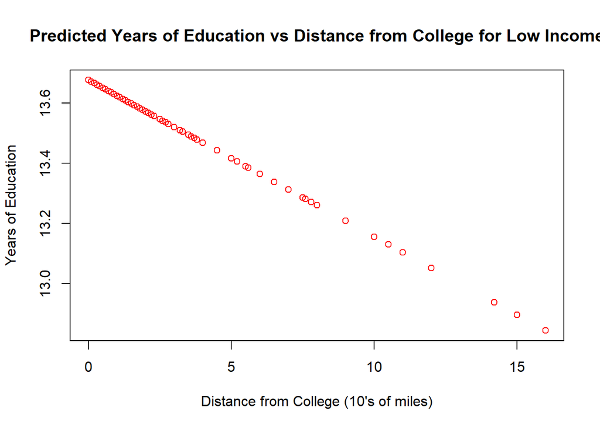

```r
yhatlow= predict(h_model, newdata=subset(CollDist,incomehi == 0))
yhathigh= predict(h_model, subset(CollDist,incomehi == 1))
plot(yhatlow~subset(CollDist,incomehi == 0)$dist, main = "Predicted Years of Education vs Distance from College for Low Income", xlab = "Distance from College (10's of miles)", ylab = "Years of Education", col = "red")
```

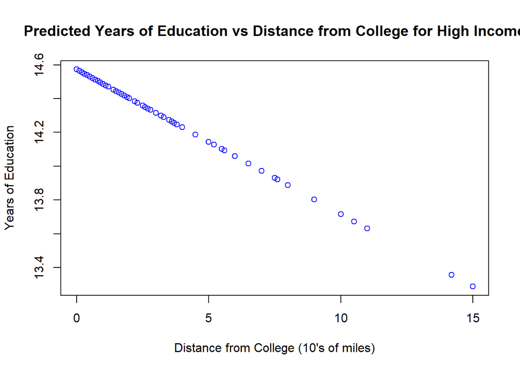

```r
plot(yhathigh~subset(CollDist,incomehi == 1)$dist, main = "Predicted Years of Education vs Distance from College for High Income", xlab = "Distance from College (10's of miles)", ylab = "Years of Education", col = "blue")
```